# Police Data

2022-01-28

## Set up the environment.

```r
knitr::opts_chunk$set(echo = TRUE)
```

```r
# Load packages.
library(tidyverse)
library(lubridate)
```

## The Data

We’re going to get NYPD case data covering the years from 2006 through 2020 and look at the distribution of cases by borough and over time. Questions to investigate include whether case counts vary over time and/or by borough.

## Get the data, view summary.

```r
# Get the data.
url_in <- "https://data.cityofnewyork.us/api/views/833y-fsy8/rows.csv?accessType=DOWNLOAD"
police_data <- read_csv(url_in)

# View a summary of the data.
summary(police_data)
```

```
##   INCIDENT_KEY        OCCUR_DATE         OCCUR_TIME           BORO
##  Min.   :  9953245   Length:23585       Length:23585      Length:23585
##  1st Qu.: 55322804   Class :character   Class1:hms        Class :character
##  Median : 83435362   Mode  :character   Class2:difftime   Mode  :character
##  Mean   :102280741                      Mode  :numeric
##  3rd Qu.:150911774
##  Max.   :230611229
##
##     PRECINCT      JURISDICTION_CODE LOCATION_DESC      STATISTICAL_MURDER_FLAG
##  Min.   :  1.00   Min.   :0.000     Length:23585       Mode :logical
##  1st Qu.: 44.00   1st Qu.:0.000     Class :character   FALSE:19085
##  Median : 69.00   Median :0.000     Mode  :character   TRUE :4500
##  Mean   : 66.21   Mean   :0.333
##  3rd Qu.: 81.00   3rd Qu.:0.000
##  Max.   :123.00   Max.   :2.000
##                   NA's   :2
##  PERP_AGE_GROUP       PERP_SEX          PERP_RACE         VIC_AGE_GROUP
##  Length:23585       Length:23585       Length:23585       Length:23585
##  Class :character   Class :character   Class :character   Class :character
##  Mode  :character   Mode  :character   Mode  :character   Mode  :character
##
##
##
##
##    VIC_SEX            VIC_RACE           X_COORD_CD        Y_COORD_CD
##  Length:23585       Length:23585       Min.   : 914928   Min.   :125757
##  Class :character   Class :character   1st Qu.: 999925   1st Qu.:182539
##  Mode  :character   Mode  :character   Median :1007654   Median :193470
##                                        Mean   :1009379   Mean   :207300
##                                        3rd Qu.:1016782   3rd Qu.:239163
##                                        Max.   :1066815   Max.   :271128
##
##     Latitude       Longitude        Lon_Lat
##  Min.   :40.51   Min.   :-74.25   Length:23585
##  1st Qu.:40.67   1st Qu.:-73.94   Class :character
##  Median :40.70   Median :-73.92   Mode  :character
##  Mean   :40.74   Mean   :-73.91
##  3rd Qu.:40.82   3rd Qu.:-73.88
##  Max.   :40.91   Max.   :-73.70
##
```

## Do some basic cleaning of the data.

```r
police_data <- police_data %>%
  # First, remove columns that are not needed.
  select(
    -c(
      INCIDENT_KEY,
      PRECINCT,
      JURISDICTION_CODE,
      LOCATION_DESC,
      STATISTICAL_MURDER_FLAG,
      X_COORD_CD,
      Y_COORD_CD,
      Lon_Lat,
      PERP_AGE_GROUP,
      PERP_RACE,
      PERP_SEX,
      VIC_AGE_GROUP,
      VIC_RACE,
      VIC_SEX,
    )
  ) %>%
  # Then fix the data types where necessary.
  mutate(OCCUR_DATE = mdy(OCCUR_DATE))

# View a summary of the cleaned data.
summary(police_data)
```

```
##    OCCUR_DATE          OCCUR_TIME           BORO              Latitude
##  Min.   :2006-01-01   Length:23585      Length:23585       Min.   :40.51
##  1st Qu.:2008-12-31   Class1:hms        Class :character   1st Qu.:40.67
##  Median :2012-02-27   Class2:difftime   Mode  :character   Median :40.70
##  Mean   :2012-10-05   Mode  :numeric                       Mean   :40.74
##  3rd Qu.:2016-03-02                                        3rd Qu.:40.82
##  Max.   :2020-12-31                                        Max.   :40.91
##    Longitude
##  Min.   :-74.25
##  1st Qu.:-73.94
##  Median :-73.92
##  Mean   :-73.91
##  3rd Qu.:-73.88
##  Max.   :-73.70
```

## Visualize the distribution of cases.

### Cases by Year

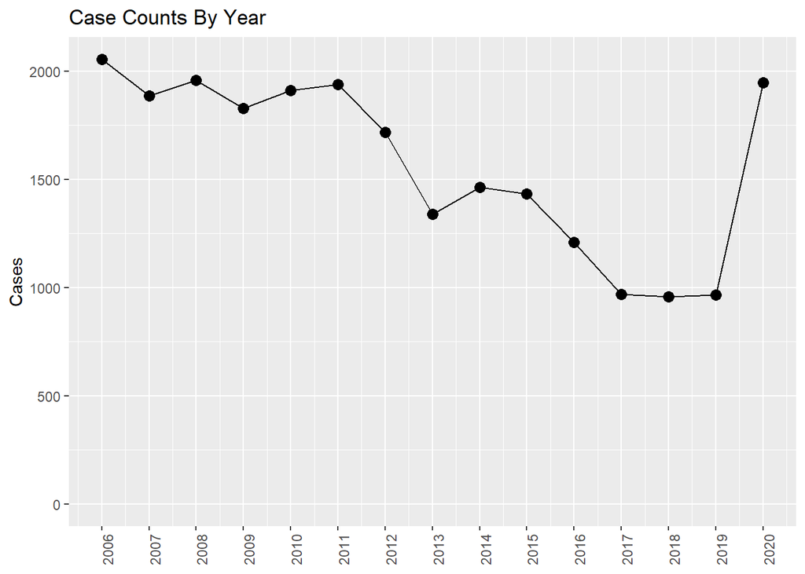

```r
# First, let's look at cases by year.
incident_count_by_year <- police_data %>%
  # To keep the year as a date object, set the day of each case to the first of the year.
  mutate(cases = 1, year = lubridate::ymd(format(OCCUR_DATE, format="%Y-01-01")))%>%
  group_by(year) %>%
  summarize(cases = sum(cases))

# Show the cases by year in a chart.
incident_count_by_year %>%
  ggplot(aes(x = year, y = cases)) +
  geom_line(aes(group=1)) +
  geom_point(color="black", size=3) +
  ylim(0, NA) +
  scale_x_date(date_labels = "%Y", date_breaks = "1 year") +
  theme(legend.position = "none", axis.text.x = element_text(angle = 90)) +
  labs(title = "Case Counts By Year", x = NULL, y = "Cases")
```

### Cases by Month

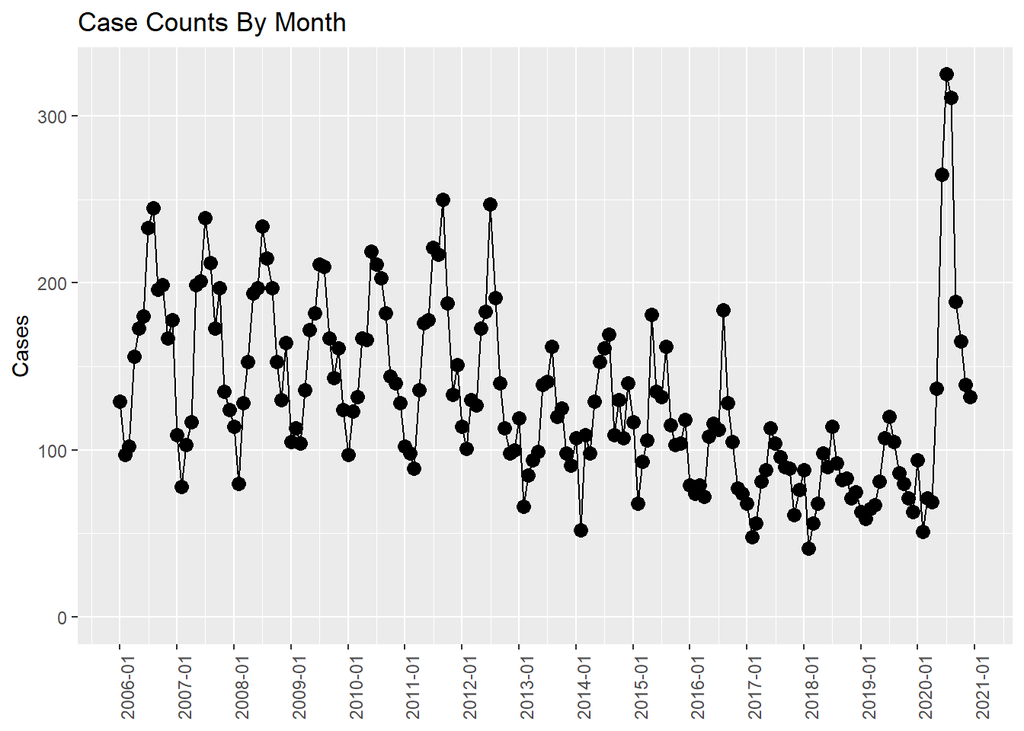

```r
# Next, let's look at cases by month.
incident_count_by_month <- police_data %>%
  # To keep the month as a date object, set the day of each case to the first of the month.
  mutate(cases = 1, month = lubridate::ymd(format(OCCUR_DATE, format="%Y-%m-01"))) %>%
  group_by(month) %>%
  summarize(cases = sum(cases))

# Show the cases by month in a chart.
incident_count_by_month %>%
  ggplot(aes(x = month, y = cases)) +
  geom_line(aes(group=1)) +
  geom_point(color="black", size=3) +
  ylim(0, NA) +
  scale_x_date(date_labels = "%Y-%m", date_breaks = "1 year") +
  theme(legend.position = "none", axis.text.x = element_text(angle = 90)) +
  labs(title = "Case Counts By Month", x = NULL, y = "Cases")
```

**Questions to consider**:

What could explain the slow decline in cases?

What could explain the sudden spike in cases – was it simply the pandemic?

How reliable and complete is this data?

### Cases by Borough

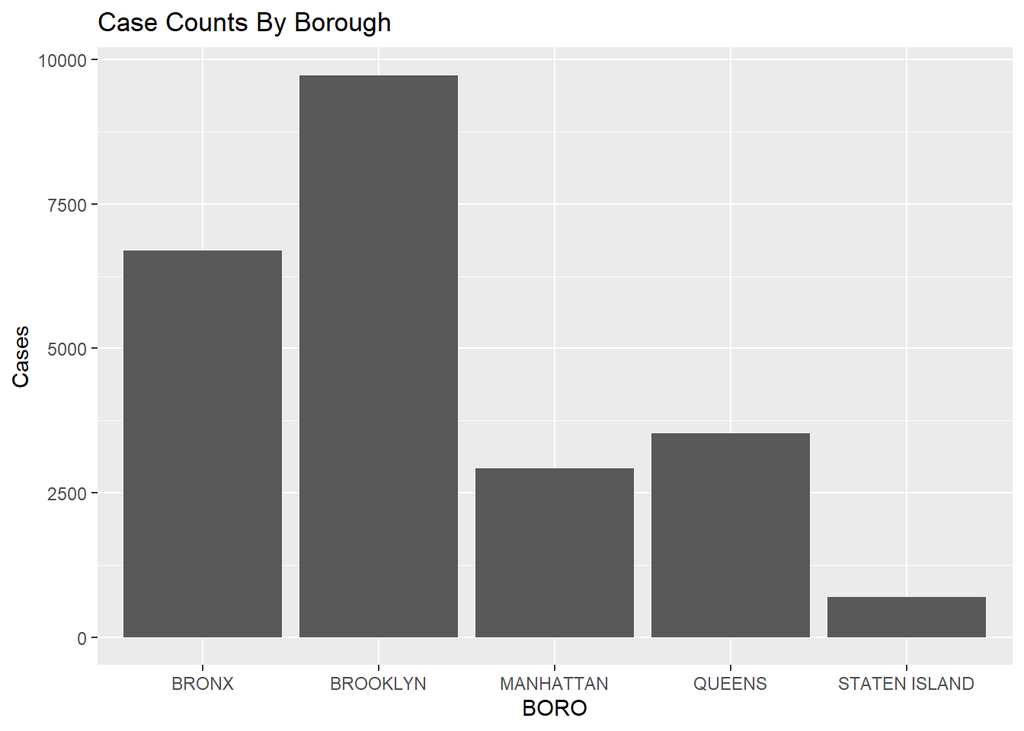

```r
# Let's look at cases by borough.
# Show the cases by borough in a chart.
police_data %>%
  ggplot(aes(x = BORO)) +
  geom_bar() +
  ylim(0, NA) +
  labs(title = "Case Counts By Borough", y = "Cases")
```

### Cases by Borough, Normalized by Population (in 2015)

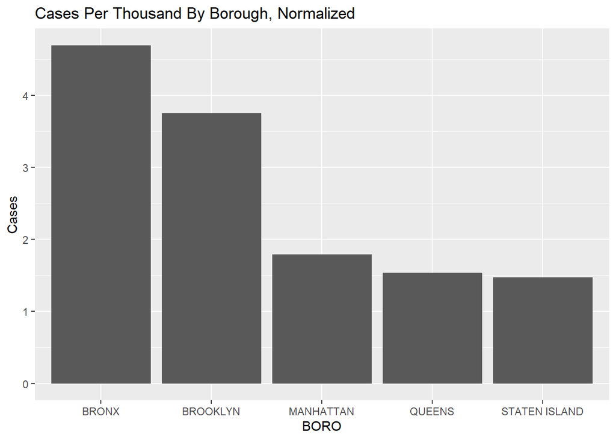

```r
# Finally, let's normalize the case by borough data.
# Show cases per thousand people by borough
cases_per_thousand_by_boro <- police_data %>%
  mutate(cases = 1) %>%
  group_by(BORO) %>%
  summarize(cases = sum(cases)) %>%
  mutate(
    population_in_2015 =
      case_when(
        BORO == "BRONX" ~ 1428000,
        BORO == "BROOKLYN" ~ 2595000,
        BORO == "MANHATTAN" ~ 1630000,
        BORO == "QUEENS" ~ 2301000,
        BORO == "STATEN ISLAND" ~ 472481
      )
  ) %>%
  summarize(BORO, cases_per_thousand = 1000 * cases / population_in_2015)

cases_per_thousand_by_boro %>%
  ggplot(aes(x = BORO, y = cases_per_thousand)) +
  geom_col() +
  ylim(0, NA) +
  labs(title = "Cases Per Thousand By Borough, Normalized", y = "Cases")
```

## Conclusions

Case data varied quite a bit over the 15 years from 2006 through 2020. With the exception of the first year of the pandemic, where cases were unusually high, there was an overall downward trend in cases from year to year, possibly coinciding with presidential terms… The monthly chart also shows a clear seasonal trend with more cases appearing in the summer months.  
Case data also varied by borough, even after normalizing for population. While the Bronx and Manhattan have similar population sizes, the Bronx has more than twice the number of cases per 1,000 people. Brooklyn and the Bronx both come in around 4 cases per 1,000 people whereas the other three boroughs are all under 2 cases per 1,000 people.

## Potential Biases

The original data had several other fields that could have been used in this analysis, but I personally felt these (cases over time and by borough) were the most interesting and straightforward to look at, so I left out things like the race and age of the parties involved.  
Also, I somewhat arbitrarily chose 2015 as the year to use for population data when normalizing the cases by borough, definitely biasing the results toward the values for that specific year. A more complete way to do this might have been to take the average yearly population for each borough over the period of time included in the case data (2006-2020)